# Advanced Macroeconomics Homework 6

Aryaman Nagpal

2024-04-03

## Question 1

### 1(a) Plots

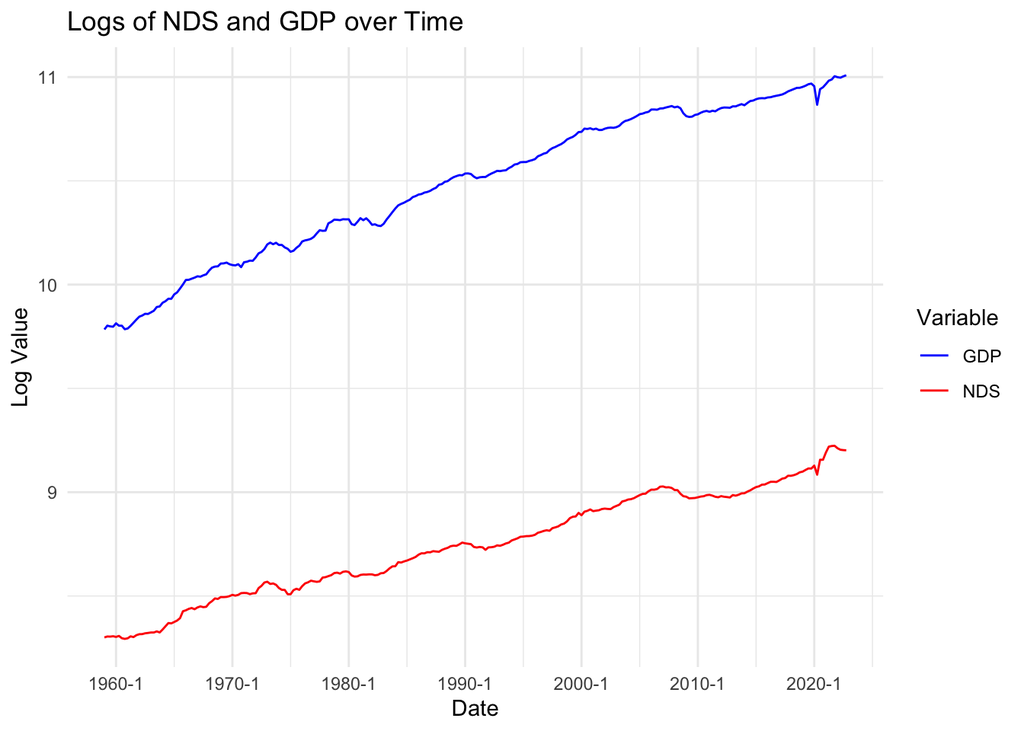

```r
data <- read.csv("/Users/aryaman/Downloads/cons_homework_csv.csv")
data$date <- as.yearqtr(data$date)

ggplot(data, aes(x = date)) +
  geom_line(aes(y = log(NDS), color = "NDS")) +
  geom_line(aes(y = log(GDP), color = "GDP")) +
  labs(title = "Logs of NDS and GDP over Time",
       x = "Date",
       y = "Log Value",
       color = "Variable") +
  scale_color_manual(values = c("blue", "red")) +
  theme_minimal()
```

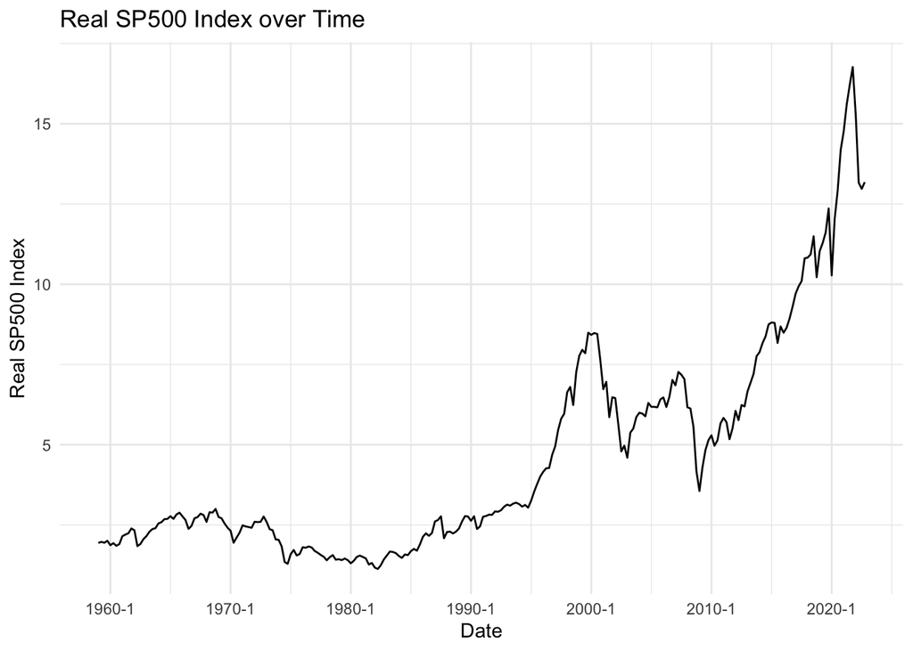

```r
ggplot(data, aes(x = date)) +
  geom_line(aes(y = SP500)) +
  labs(title = "Real SP500 Index over Time",
       x = "Date",
       y = "Real SP500 Index") +
  theme_minimal()
```

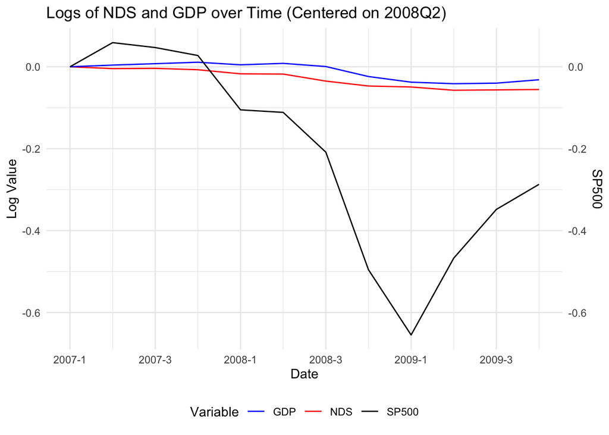

```r
# Creating restricted data for centered plots
data_2008 <- data[data$year >= "2007" & data$year <= "2009", ]
data_2008$GDP <- data_2008$GDP / data$GDP[data$date == "2007q1"]
data_2008$NDS <- data_2008$NDS / data$NDS[data$date == "2007q1"]
data_2008$SP500 <- data_2008$SP500 / data$SP500[data$date == "2007q1"]

data_2020 <- data[data$year >= "2019" & data$year <= "2020", ]
data_2020$GDP <- data_2020$GDP / data$GDP[data$date == "2019q1"]
data_2020$NDS <- data_2020$NDS / data$NDS[data$date == "2019q1"]
data_2020$SP500 <- data_2020$SP500 / data$SP500[data$date == "2019q1"]

ggplot(data_2008, aes(x = date)) +
  geom_line(aes(y = log(NDS), color = "NDS")) +
  geom_line(aes(y = log(GDP), color = "GDP")) +
  geom_line(aes(y = log(SP500), color = "SP500")) +
  labs(title = "Logs of NDS and GDP over Time (Centered on 2008Q2)",
       x = "Date",
       y = "Log Value",
       color = "Variable") +
  scale_color_manual(values = c("blue", "red", "black")) +
  theme_minimal() +
  theme(legend.position = "bottom") +
  scale_y_continuous(
    sec.axis = sec_axis(~ ., name = "SP500", breaks = scales::pretty_breaks())
  )
```

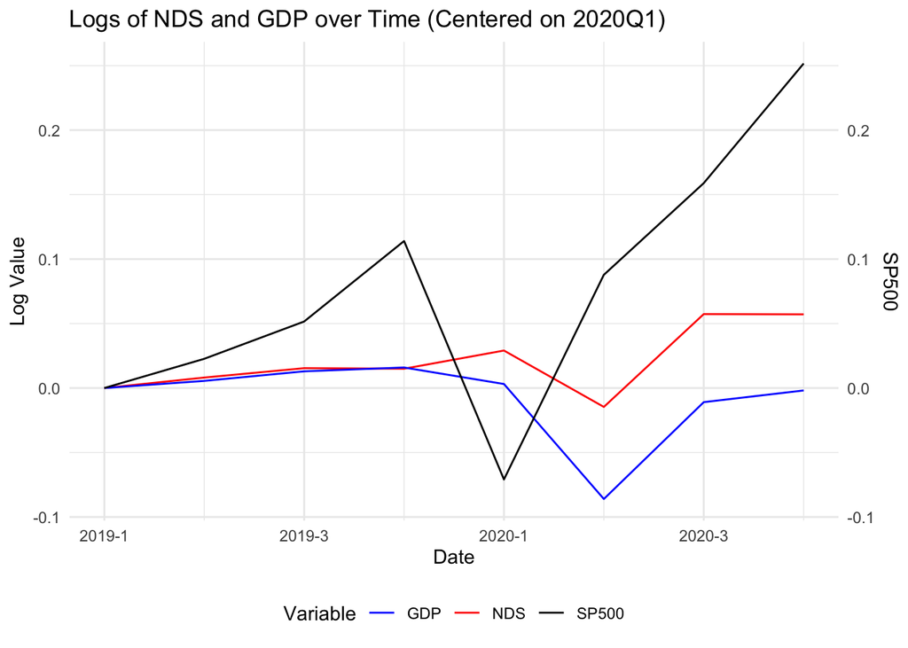

```r
ggplot(data_2020, aes(x = date)) +
  geom_line(aes(y = log(NDS), color = "NDS")) +
  geom_line(aes(y = log(GDP), color = "GDP")) +
  geom_line(aes(y = log(SP500), color = "SP500")) +
  labs(title = "Logs of NDS and GDP over Time (Centered on 2020Q1)",
       x = "Date",
       y = "Log Value",
       color = "Variable") +
  scale_color_manual(values = c("blue", "red", "black")) +
  theme_minimal() +
  theme(legend.position = "bottom") +
  scale_y_continuous(
    sec.axis = sec_axis(~ ., name = "SP500", breaks = scales::pretty_breaks())
 )
```

During the 2008 recession, the stock market fell drastically, experiencing a log drop of more than 0.6 from the beginning of 2007 to the beginning of 2009. Consumption and income dipped as well, but far less than the stock market. Relative to 2007q1, consumption dropped slightly more than income during the recession. Log income dropped by around 0.03 while consumption dropped by around 0.05 across this period.

During the pandemic, we see that the stock market experienced the shock before income and consumption, dropping by about 0.07 in logs relative to the beginning of 2019. GDP and consumption dropped less steeply than the stock market. Income dropped lower and steeper than consumption during this period. Consumption dropped the least out of the three variables in logs during the pandemic.

### 1(b) Growth Rates

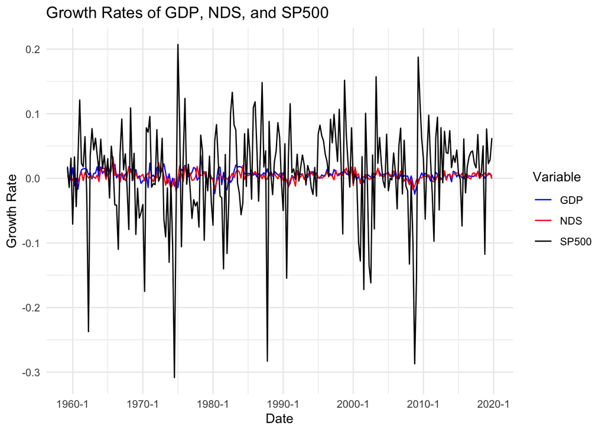

```r
data$delta_log_GDP <- c(NA, diff(log(data$GDP)))
data$delta_log_NDS <- c(NA, diff(log(data$NDS)))
data$delta_log_SP500 <- c(NA, diff(log(data$SP500)))

# I will now restrict the data to observations until 2019Q4
data_res <- data[data$date <= "2019q4", ]



growth_rates <- data.frame(date = data_res$date,
                       delta_log_GDP = data_res$delta_log_GDP,
                       delta_log_NDS = data_res$delta_log_NDS,
                       delta_log_SP500 = data_res$delta_log_SP500)

growth_rates <- growth_rates[-1,]

ggplot(growth_rates, aes(x = date)) +
  geom_line(aes(y = delta_log_GDP, color = "GDP")) +
  geom_line(aes(y = delta_log_NDS, color = "NDS")) +
  geom_line(aes(y = delta_log_SP500, color = "SP500")) +
  labs(title = "Growth Rates of GDP, NDS, and SP500",
       x = "Date",
       y = "Growth Rate",
       color = "Variable") +
  scale_color_manual(values = c("blue", "red", "black")) +
  theme_minimal()
```

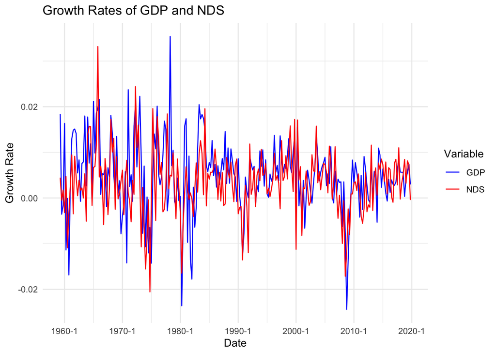

```r
ggplot(growth_rates, aes(x = date)) +
  geom_line(aes(y = delta_log_GDP, color = "GDP")) +
  geom_line(aes(y = delta_log_NDS, color = "NDS")) +
  labs(title = "Growth Rates of GDP and NDS",
       x = "Date",
       y = "Growth Rate",
       color = "Variable") +
  scale_color_manual(values = c("blue", "red")) +
  theme_minimal()
```

I have provided one plot with the growth rates of all three variables. The growth rate of the stock market is clearly far more volatile than that of consumption and income, so I plotted just income and consumption growth rates in a separate plot to observe them on a more appropriate scale.

### 1(c) Summary Statistics for Growth Rates

```r
stargazer(growth_rates, type='latex',
          title = "Summary Statistics for Growth Rates")
```

### 1(d) Growth Rates Correlation Matrix

```r
correlation_matrix <- cor(growth_rates[, c("delta_log_GDP",
                                           "delta_log_NDS", "delta_log_SP500")])

kable(correlation_matrix,
      caption = "Correlation matrix between growth rates",
      format = "latex",
      booktabs = TRUE,
      digits = 2)
```

We observe a moderate correlation ($\rho = 0.58$) between consumption and income growth, and low correlation between the stock market and both consumption and income growth. However, stock market growth is slightly more correlated with consumption growth ($\rho = 0.24$) than with income growth ($\rho = 0.15$).

### 1(e)

```r
acf_gdp <- acf(diff(data_res$GDP), lag.max = 4, plot = FALSE)
acf_nds <- acf(diff(data_res$NDS), lag.max = 4, plot = FALSE)
acf_sp500 <- acf(diff(data_res$SP500), lag.max = 4, plot = FALSE)

autocorrelations <- data.frame(
  Lag = 0:4,
  GDP = acf_gdp$acf,
  NDS = acf_nds$acf,
  SP500 = acf_sp500$acf
)

kable(autocorrelations,
      caption = "Autocorrelations of Variables of Interest,
      Lagged from 0-4 Periods",
      format = "latex",
      position = "h",
      booktabs = TRUE,
      digits = 3)
```

### 1(f)

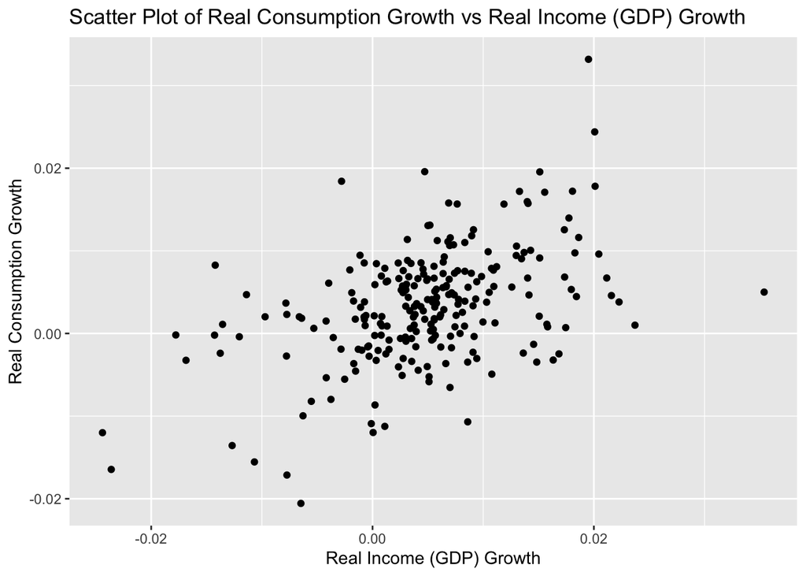

```r
ggplot(data_res, aes(x = delta_log_GDP, y = delta_log_NDS)) +
  geom_point() +
  labs(title = "Scatter Plot of Real Consumption Growth vs Real Income (GDP) Growth",
       x = "Real Income (GDP) Growth",
       y = "Real Consumption Growth")
```

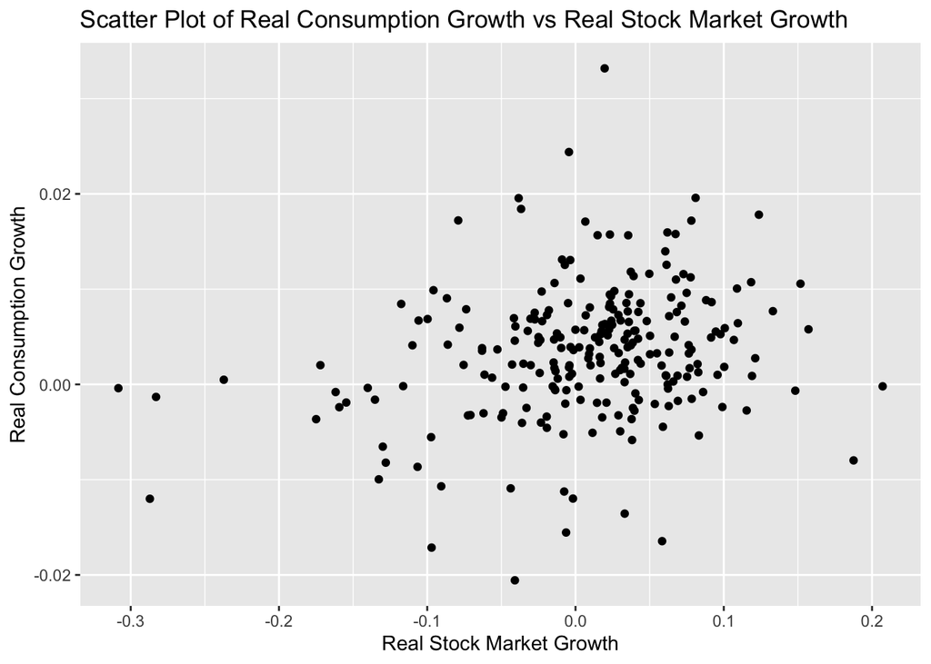

```r
ggplot(data_res, aes(x = delta_log_SP500, y = delta_log_NDS)) +
  geom_point() +
  labs(title = "Scatter Plot of Real Consumption Growth vs Real Stock Market Growth",
       x = "Real Stock Market Growth",
       y = "Real Consumption Growth")
```

## Question 2

We seek to test whether consumption truly follows a random walk by regressing the growth of consumption at time $t$ on values of consumption, income, and stock market growth known at time $t-1$. We denote the set of these variables as $X_{t-1}$. We will first regress consumption growth against one period lagged values of consumption, income, and stock market growth, i.e.
$$\begin{aligned}
\Delta \ln{(NDS_t)} &= \alpha + \beta\left[\Delta
\ln{(NDS_{t-1})}\right] + \epsilon_t && \text{(1)} \\
\Delta \ln{(NDS_t)} &= \alpha + \beta\left[\Delta
\ln{(GDP_{t-1})}\right] + \epsilon_t && \text{(2)} \\
\Delta \ln{(NDS_t)} &= \alpha + \beta\left[\Delta
\ln{(SP_{t-1})}\right] + \epsilon_t && \text{(3)} \\
\end{aligned}$$
$$\begin{aligned}
\Delta \ln{(NDS_t)} &= \alpha + \beta_1\left[\Delta
\ln{(NDS_{t-1})}\right] +
\beta_2\left[\Delta \ln{(GDP_{t-1})}\right] +
\beta_3\left[\Delta \ln{(SP_{t-1})}\right] + \epsilon_t &&
\text{(4)}
\end{aligned}$$

```r
model_NDSlag1 <- lm(delta_log_NDS ~ lag(delta_log_NDS, 1), data = data_res)
model_GDPlag1 <- lm(delta_log_NDS ~ lag(delta_log_GDP, 1), data = data_res)
model_SPlag1 <- lm(delta_log_NDS ~ lag(delta_log_SP500, 1), data = data_res)
model_combinedlag1 <- lm(delta_log_NDS ~ lag(delta_log_NDS, 1)
                     + lag(delta_log_GDP, 1)
                     + lag(delta_log_SP500, 1), data = data_res)

stargazer(model_NDSlag1, model_GDPlag1, model_SPlag1,
          title="Consumption Growth vs. One-Period Lagged
          Variables (Separate)",
          header=FALSE)
```

```r
stargazer(model_combinedlag1,
          title="Consumption Growth vs. One-Period Lagged
          Variables (Combined)",
          column.labels="(4)",
          header=FALSE)
```

We observe that when regressing consumption growth against one period lagged values of consumption, income, and stock market growth separately, the coefficients are all statistically significant at the 1% level, suggesting that $b \neq 0$. When we combine all three, one-period lagged consumption is no longer statistically significant, but both income and stock market growth remain statistically significant at the 1% level. Let the vector $L_{t-i} = \{\Delta \ln{(NDS_{t-i})},\:\Delta \ln{(GDP_{t-i})},\:\Delta \ln{(SP_{t-i})}\}$ and let $\beta_{L_{t-i}}$ denote the vector of corresponding OLS coefficients. We will now add two-period lagged variables into these regressions by estimating:
$$\begin{aligned}
\Delta \ln{(NDS_t)} &= \alpha + \beta_{L_{t-1}}\left[L_{t-1}\right]
+ \beta_4\left[\Delta \ln{(NDS_{t-2})}\right] + \epsilon_t &&
\text{(5)} \\
\Delta \ln{(NDS_t)} &= \alpha + \beta_{L_{t-1}}\left[L_{t-1}\right]
+ \beta_4\left[\Delta \ln{(GDP_{t-2})}\right] + \epsilon_t &&
\text{(6)} \\
\Delta \ln{(NDS_t)} &= \alpha + \beta_{L_{t-1}}\left[L_{t-1}\right]
+ \beta_4\left[\Delta \ln{(SP_{t-2})}\right] + \epsilon_t &&
\text{(7)}
\end{aligned}$$

```r
model_combinedNDS2 <- lm(delta_log_NDS ~ lag(delta_log_NDS, 1)
                     + lag(delta_log_GDP, 1)
                     + lag(delta_log_SP500, 1)
                     + lag(delta_log_NDS, 2),
                     data = data_res)
model_combinedGDP2 <- lm(delta_log_NDS ~ lag(delta_log_NDS, 1)
                     + lag(delta_log_GDP, 1)
                     + lag(delta_log_SP500, 1)
                     + lag(delta_log_GDP, 2),
                     data = data_res)
model_combinedSP2 <- lm(delta_log_NDS ~ lag(delta_log_NDS, 1)
                     + lag(delta_log_GDP, 1)
                     + lag(delta_log_SP500, 1)
                     + lag(delta_log_SP500, 2),
                     data = data_res)
stargazer(model_combinedNDS2, model_combinedGDP2, model_combinedSP2,
          title = "Consumption Growth vs. One-Period Lagged Variables with Add. Lags (Separate)",
          column.labels = c("(5)", "(6)", "(7)"),
          model.numbers = FALSE,
          header=FALSE)
```

```r
model_combinedlags <- lm(delta_log_NDS ~ lag(delta_log_GDP, 1)
                     + lag(delta_log_GDP, 2)
                     + lag(delta_log_GDP, 3)
                     + lag(delta_log_GDP, 4)
                     + lag(delta_log_SP500, 1), data = data_res)
model_combinedlags12 <- lm(delta_log_NDS ~ lag(delta_log_GDP, 1)
                     + lag(delta_log_GDP, 2)
                     + lag(delta_log_SP500, 1), data = data_res)
stargazer(model_combinedlags, model_combinedlags12,
          title="Consumption Growth vs.
          Chosen Lagged Variables (Combined)",
          column.labels=c("(8)", "(9)"),
          model.numbers=FALSE,
          header=FALSE)
```

Since all variables in regression (9) are significant at the 1% level and the adjusted $R^2$ value drops very slightly after omitting the insignificant covariates from regression (8), we conclude that approximately 18.2% of the variation in consumption growth can be determined by income growth lagged by one and two periods, and stock market growth lagged by one period. Lagged income has a more acute effect on consumption growth than lagged stock market growth does, suggested by the relative magnitudes of the calculated coefficients.

Thus, we can conclude that consumption does not fully follow a true random walk. Rather, approximately a fifth of the variation in consumption growth can be explained by previous income and stock market growth.

## Question 3

### 3(a) Forecasting Future Income Growth

We seek to find a vector of variables known at time $t-1$, $X_{t-1}$, which predict income growth at time $t$. I will first run three regressions of income growth on lagged values of the three variables of interest. We will estimate:
$$\begin{aligned}
\Delta \ln{(GDP_t)} &= \alpha + \sum^4_{i=1}\beta_i\left[\Delta
\ln{(GDP_{t-i})}\right] + \epsilon_t && \text{(10)} \\
\Delta \ln{(GDP_t)} &= \alpha + \sum^4_{i=1}\beta_i\left[\Delta
\ln{(NDS_{t-i})}\right] + \epsilon_t && \text{(11)} \\
\Delta \ln{(GDP_t)} &= \alpha + \sum^4_{i=1}\beta_i\left[\Delta
\ln{(SP_{t-i})}\right] + \epsilon_t && \text{(12)}
\end{aligned}$$

```r
incgrowth_GDPlag <- lm(delta_log_GDP ~ lag(delta_log_GDP, 1)
                       + lag(delta_log_GDP, 2)
                       + lag(delta_log_GDP, 3)
                       + lag(delta_log_GDP, 4), data = data_res)

incgrowth_NDSlag <- lm(delta_log_GDP ~ lag(delta_log_NDS, 1)
                       + lag(delta_log_NDS, 2)
                       + lag(delta_log_NDS, 3)
                       + lag(delta_log_NDS, 4), data = data_res)

incgrowth_SP500lag <- lm(delta_log_GDP ~ lag(delta_log_SP500, 1)
                       + lag(delta_log_SP500, 2)
                       + lag(delta_log_SP500, 3)
                       + lag(delta_log_SP500, 4), data = data_res)

stargazer(incgrowth_GDPlag, incgrowth_NDSlag, incgrowth_SP500lag,
          title="Income Growth vs. Lagged Variables (Separate)",
          column.labels=c("(10)", "(11)", "(12)"),
          model.numbers=FALSE,
          header=FALSE)
```

The six covariates statistically significant at the 1% significance level in predicting future income growth are one and two period lags of all three of the variables of interest. I will first regress future income growth on each of the three variables lagged by one period. I will then run three further regressions of income growth on $L_{t-1}$ and two-period lagged values of each of the three variables separately.
$$\begin{aligned}
\Delta \ln{(GDP_t)} &= \alpha + \beta_{L_{t-1}}\left[L_{t-1}\right]
+ \epsilon_t && \text{(13)} \\
\Delta \ln{(GDP_t)} &= \alpha + \beta_{L_{t-1}}\left[L_{t-1}\right]
+ \beta_4\left[\Delta \ln{(GDP_{t-2})}\right] + \epsilon_t &&
\text{(14)} \\
\Delta \ln{(GDP_t)} &= \alpha + \beta_{L_{t-1}}\left[L_{t-1}\right]
+ \beta_4\left[\Delta \ln{(NDS_{t-2})}\right] + \epsilon_t &&
\text{(15)} \\
\Delta \ln{(GDP_t)} &= \alpha + \beta_{L_{t-1}}\left[L_{t-1}\right]
+ \beta_4\left[\Delta \ln{(SP_{t-2})}\right] + \epsilon_t &&
\text{(16)}
\end{aligned}$$

```r
inc_growth_base <- lm(delta_log_GDP ~ lag(delta_log_GDP, 1)
                     + lag(delta_log_NDS, 1)
                     + lag(delta_log_SP500, 1),
                     data = data_res)

stargazer(inc_growth_base, title="Income Growth vs.
          One-Period Lagged Variables",
          column.labels="(13)",
          header=FALSE)
```

```r
inc_growth_GDP2 <- lm(delta_log_GDP ~ lag(delta_log_GDP, 1)
                     + lag(delta_log_NDS, 1)
                     + lag(delta_log_SP500, 1)
                     + lag(delta_log_GDP, 2),
                     data = data_res)
inc_growth_NDS2 <- lm(delta_log_GDP ~ lag(delta_log_GDP, 1)
                     + lag(delta_log_NDS, 1)
                     + lag(delta_log_SP500, 1)
                     + lag(delta_log_NDS, 2),
                     data = data_res)
inc_growth_SP5002 <- lm(delta_log_GDP ~ lag(delta_log_GDP, 1)
                     + lag(delta_log_NDS, 1)
                     + lag(delta_log_SP500, 1)
                     + lag(delta_log_SP500, 2),
                     data = data_res)

stargazer(inc_growth_GDP2,
          inc_growth_NDS2, inc_growth_SP5002,
          title="Income Growth vs. One and Two-Period Lagged Variables",
          column.labels=c("(14)", "(15)", "(16)"),
          model.numbers=FALSE,
          header=FALSE)
```

```r
inc_growth_NDS2_SP5002 <- lm(delta_log_GDP ~ lag(delta_log_GDP, 1)
                          + lag(delta_log_NDS, 1)
                          + lag(delta_log_SP500, 1)
                          + lag(delta_log_NDS, 2)
                          + lag(delta_log_SP500, 2),
                          data = data_res)

inc_growth_model <- lm(delta_log_GDP ~ lag(delta_log_NDS, 1)
                          + lag(delta_log_SP500, 1)
                          + lag(delta_log_NDS, 2)
                          + lag(delta_log_SP500, 2),
                          data = data_res)

stargazer(inc_growth_NDS2_SP5002, inc_growth_model,
          title="Income Growth vs. Chosen Lagged Variables",
          model.numbers=FALSE,
          column.labels=c("(17)","(18)"),
          header=FALSE)
```

By omitting this variable, the regression now has an adjusted $R^2$ value of $0.209$, a very small drop from the adjusted $R^2$ value from the previous regression. Further, all of the coefficients are now statistically significant at the 1% level, including the constant. We thus conclude that future income growth is likely best estimated by regression (18). Our determined vector of four covariates is then
$$X_{t-1} = \{\ln{(NDS_{t-1})}, \Delta
\ln{(SP_{t-1})}, \Delta \ln{(NDS_{t-2})}, \Delta
\ln{(SP_{t-2})}\}$$

### 3(b)

We will estimate two models:
$$\begin{aligned}
\Delta \ln{(NDS_t)} &= a_c + b'_cX_{t-1} + u_t \\
\Delta \ln{(GDP_t)} &= a_y + b'_yX_{t-1} + v_t
\end{aligned}$$
The following plot shows the values of income growth against values of consumption growth fitted by the above regressions.

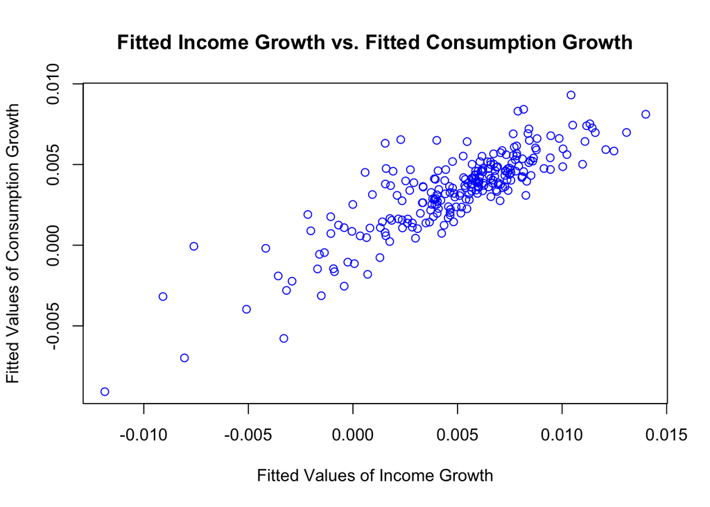

```r
NDSt_model <- lm(delta_log_NDS ~ lag(delta_log_NDS, 1)
                          + lag(delta_log_SP500, 1)
                          + lag(delta_log_NDS, 2)
                          + lag(delta_log_SP500, 2),
                          data = data_res)

GDPt_model <- lm(delta_log_GDP ~ lag(delta_log_NDS, 1)
                          + lag(delta_log_SP500, 1)
                          + lag(delta_log_NDS, 2)
                          + lag(delta_log_SP500, 2),
                          data = data_res)
fitted_NDSt <- predict(NDSt_model)
fitted_GDPt <- predict(GDPt_model)

plot(fitted_GDPt, fitted_NDSt, xlab = "Fitted Values of Income Growth",
     ylab = "Fitted Values of Consumption Growth",
     main = "Fitted Income Growth vs. Fitted Consumption Growth",
     col = "blue")
```

[figure not shown]

```r
plot(delta_log_GDP ~ delta_log_NDS,
       data = data_res,
       cex = 0.6,
       xlab = "Income Growth",
       ylab = "Consumption Growth",
       main = " Income Growth vs. Consumption Growth with Fitted Values")
points(fitted_GDPt, fitted_NDSt, col="blue")
```

I have plotted the fitted values alone as well as the fitted values alongside the original values for comparison. We can see that the fitted values have a far stronger linear relationship with a much tighter distribution. If the Campbell-Mankiw model holds, then we should see that the coefficients of the above two regression equations should satisfy
$$\frac{b_c}{b_y} = \lambda \approx
0.5$$
which implies that $b_y$ should be twice as large in magnitude as the coefficient $b_c$ according to Campbell and Mankiw’s approximation of $\lambda \approx 0.5$.

### 3(c)

We now run an IV regression of consumption growth on income growth with $X_{t-1}$ as instrumental variables.

```r
iv_model <- ivreg(delta_log_NDS ~ delta_log_GDP | lag(delta_log_NDS, 1)
                                + lag(delta_log_SP500, 1)
                                + lag(delta_log_NDS, 2)
                                + lag(delta_log_SP500, 2),
                                data = data_res)

stargazer(iv_model)
```

The observed coefficient corresponds to an estimate of $\lambda = 0.573$ significant at the 1% level. This provides strong evidence that consumption does not follow a random walk. The estimate is slightly larger than that of Campbell and Mankiw. The value implies that over half of consumption growth is determined by income growth, and the remaining proportion, less than half, follows a random-walk.

## Question 4

The pandemic had a profound effect on the economy and likely made consumers more conservative with their spending on nondurables, tying their consumption with income more than any surprise news in that period. This would, theoretically, increase $\lambda$ as consumption would be more related to income than follow a random walk. We construct an indicator variable $PAN_t$ to model and control for the effect of the pandemic.

```r
data$pandemic <- ifelse(data$year >= 2020, 1, 0)
```

$$\begin{aligned}
\Delta \ln{(GDP_t)} &= \alpha + \sum^4_{i=1}\beta_i\left[\Delta
\ln{(PAN_{t-i})}\right] + \epsilon_t && \text{(20)} \\
\Delta \ln{(NDS_t)} &= \alpha + \sum^4_{i=1}\beta_i\left[\Delta
\ln{(PAN_{t-i})}\right] + \epsilon_t && \text{(21)} \\
\Delta \ln{(SP_t)} &= \alpha + \sum^4_{i=1}\beta_i\left[\Delta
\ln{(PAN_{t-i})}\right] + \epsilon_t && \text{(22)}
\end{aligned}$$

```r
incgrowth_pandemic_GDP <- lm(delta_log_GDP ~ lag(pandemic, 1)
                             + lag(pandemic, 2)
                             + lag(pandemic, 3)
                             + lag(pandemic, 4),
                             data = data)

incgrowth_pandemic_NDS <- lm(delta_log_NDS ~ lag(pandemic, 1)
                             + lag(pandemic, 2)
                             + lag(pandemic, 3)
                             + lag(pandemic, 4),
                             data = data)

incgrowth_pandemic_SP500 <- lm(delta_log_SP500 ~ lag(pandemic, 1)
                                + lag(pandemic, 2)
                                + lag(pandemic, 3)
                                + lag(pandemic, 4),
                                data = data)
stargazer(incgrowth_pandemic_GDP, incgrowth_pandemic_NDS,
          incgrowth_pandemic_SP500,
          title = "Regression Results with Lagged Pandemic Variables",
          model.numbers=FALSE,
          column.labels=c("(20)", "(21)","(22)"),
          header=FALSE)
```

We observe that the pandemic indicator variables, lagged up to three periods, is statistically significant in predicting growth in both consumption and income. We can then run one regression using the same set of determining variables $X_{t-1}$ including the pandemic data, and another regression using $X_{t-1}$ as well as the set of pandemic lag variables $P_{t-1} = \{PAN_{t-1}, PAN_{t-2}, PAN_{t-3}\}$.
$$\begin{aligned}
\Delta\ln{(NDS_t)} &= \alpha + \beta X_{t-1} + \epsilon_t &&
\text{(23)} \\
\Delta\ln{(NDS_t)} &= \alpha + \beta_x X_{t-1} + \beta_pP_{t-1} +
\epsilon_t && \text{(24)}
\end{aligned}$$

```r
iv_model_without_pandemic <- ivreg(delta_log_NDS ~ delta_log_GDP | lag(delta_log_NDS, 1)
                                  + lag(delta_log_SP500, 1)
                                  + lag(delta_log_NDS, 2)
                                  + lag(delta_log_SP500, 2),
                                  data = data)
iv_model_with_pandemic <- ivreg(delta_log_NDS ~ delta_log_GDP | lag(delta_log_NDS, 1)
                                + lag(delta_log_NDS, 2)
                                + lag(delta_log_SP500, 1)
                                + lag(delta_log_SP500, 2)
                                + lag(pandemic, 1)
                                + lag(pandemic, 2)
                                + lag(pandemic, 3),
                                data = data)
stargazer(iv_model_without_pandemic, iv_model_with_pandemic,
          type = "latex",
          title = "IV Regression Results with Pandemic Data Included",
          column.labels = c("uncontrolled (23)", "controlled (24)"),
          model.numbers = FALSE,
          header = FALSE)
```

If we omit the indicator for the pandemic and run the IV regression with the same set of determining variables $X_{t-1}$ on the full data, the observed lambda value increases significantly from $\lambda = 0.573$ to $\lambda = 0.877$. When including the set of pandemic lags $P_{t-1}$ directly into the IV regression as a determining factor of income growth, the observed lambda value decreases to $0.683$, still larger than the observed lambda in the restricted data set. This suggests that when including the pandemic, agents tend to determine their consumption based more heavily on income as opposed to surprises. When controlling for the pandemic, however, this effect is less pronounced, but still existent.

We must check if, when including and controlling for the pandemic, the set of variables $X_{t-1}$ chosen to predict future income growth are still applicable. Therefore, we may need to refine $X_{t-1}$ taking into account the lagged effect of the pandemic. We thus run regressions on each of the three variables of interest against their own lags as well as the lagged pandemic values for one, two, and three periods.

```r
incgrowth_GDPlag_with_pandemic <- lm(delta_log_GDP ~ lag(delta_log_GDP, 1)
                                     + lag(delta_log_GDP, 2)
                                     + lag(delta_log_GDP, 3)
                                     + lag(delta_log_GDP, 4)
                                     + lag(pandemic, 1)
                                     + lag(pandemic, 2)
                                     + lag(pandemic, 3),
                                     data = data)
incgrowth_NDSlag_with_pandemic <- lm(delta_log_GDP ~ lag(delta_log_NDS, 1)
                                     + lag(delta_log_NDS, 2)
                                     + lag(delta_log_NDS, 3)
                                     + lag(delta_log_NDS, 4)
                                     + lag(pandemic, 1)
                                     + lag(pandemic, 2)
                                     + lag(pandemic, 3),
                                     data = data)
incgrowth_SP500lag_with_pandemic <- lm(delta_log_GDP ~ lag(delta_log_SP500, 1)
                                       + lag(delta_log_SP500, 2)
                                       + lag(delta_log_SP500, 3)
                                       + lag(delta_log_SP500, 4)
                                       + lag(pandemic, 1)
                                       + lag(pandemic, 2)
                                       + lag(pandemic, 3),
                                       data = data)
```

```r
inc_growth_model_with_pandemic <- lm(delta_log_GDP ~ lag(delta_log_GDP, 1)
                                    + lag(delta_log_GDP, 2)
                                    + lag(delta_log_NDS, 1)
                                    + lag(delta_log_NDS, 2)
                                    + lag(delta_log_SP500, 1)
                                    + lag(delta_log_SP500, 2)
                                    + lag(pandemic, 1)
                                    + lag(pandemic, 2)
                                    + lag(pandemic, 3),
                                    data = data)
```

```r
inc_growth_model_with_pandemic <- lm(delta_log_GDP ~ lag(delta_log_NDS, 1)
                                    + lag(delta_log_NDS, 2)
                                    + lag(delta_log_SP500, 1)
                                    + lag(delta_log_SP500, 2)
                                    + lag(pandemic, 1)
                                    + lag(pandemic, 2)
                                    + lag(pandemic, 3),
                                    data = data)
stargazer(inc_growth_model_with_pandemic, header=FALSE,
          title = "Income Growth vs. Lagged Consumption Growth,
          Stock Market Growth, and Pandemic Variables")
```

Now, all covariates are significant at the 1% level, except stock market data lagged by two periods which is significant at the 5% level. The adjusted $R^2$ value of this regression is $0.567$, a remarkable improvement from the model we ran for forecasting income growth without the pandemic data included. Our set of covariates when considering the pandemic $X^p_{t-1}$ are the same as the previous investigation we ran on the restricted data, with the addition of the three lagged values of the pandemic variable.
$$X^p_{t-1} = X_{t-1} + P_{t-1} =$$
$$\{\Delta\ln{(NDS_{t-1})},\;\Delta\ln{(NDS_{t-2})},\;\Delta\ln{(SP_{t-1})},\;\Delta\ln{(SP_{t-2})},\;PAN_{t-1},\;
PAN_{t-2},\; PAN_{t-3} \}$$

Thus, the lambda value calculated in the controlled pandemic IV regression, Eq. (24), is likely the best estimate we have after including the pandemic data. It is more robust to include the pandemic data and control for it than to simply omit it. The lambda increased by 19.2% after including and controlling for the pandemic, which is a relatively significant increase. I believe that it is necessary to consider the result after including and controlling for the pandemic as it gives the most accurate representation of agent consumption behavior right now considering that the pandemic has recently happened.

The ripple effects of the pandemic are still reflected in the economy today, and it is thus important to recognize that more consumers are now hand-to-mouth as opposed to following the permanent income hypothesis, and this effect may persist for a considerable period. This should, however, be taken with a grain of salt as consumer consumption behavior may revert to back to its pre-pandemic norms over time.